# Nobel Prize Jupyter

```python
import os

os.system('jupyter nbconvert --to html yourNotebook.ipynb')
```

```
-1
```

[figure not shown]

The Nobel Prize is perhaps the world's most well known scientific award. Except for the honor, prestige and substantial prize money the recipient also gets a gold medal showing Alfred Nobel (1833 - 1896) who established the prize. Every year it's given to scientists and scholars in the categories chemistry, literature, physics, physiology or medicine, economics, and peace. The first Nobel Prize was handed out in 1901, and at that time the Prize was very Eurocentric and male-focused, but nowadays it's not biased in any way whatsoever. Surely.

Well, we're going to find out! The Nobel Foundation has made a dataset available of all prize winners from the start of the prize, in 1901, to 2016.

```python
import pandas as pd
import seaborn as sns
import numpy as np
import matplotlib.pyplot as plt

# Reading in the Nobel Prize data
data = pd.read_csv(r'C:\Users\Adam\Desktop\Personal\Python Projects\Github\3) Nobel-Prizes\Nobel Prize Data.csv')

data.head()
```

|  | Year | Category | Prize | Motivation | Prize Share | Laureate ID | Laureate Type | Full Name | Birth Date | Birth City | Birth Country | Sex | Organization Name | Organization City | Organization Country | Death Date | Death City | Death Country |
| --- | --- | --- | --- | --- | --- | --- | --- | --- | --- | --- | --- | --- | --- | --- | --- | --- | --- | --- |
| 0 | 1901 | Chemistry | The Nobel Prize in Chemistry 1901 | "in recognition of the extraordinary services ... | 1/1 | 160 | Individual | Jacobus Henricus van 't Hoff | 1852-08-30 | Rotterdam | Netherlands | Male | Berlin University | Berlin | Germany | 1911-03-01 | Berlin | Germany |
| 1 | 1901 | Literature | The Nobel Prize in Literature 1901 | "in special recognition of his poetic composit... | 1/1 | 569 | Individual | Sully Prudhomme | 1839-03-16 | Paris | France | Male | NaN | NaN | NaN | 1907-09-07 | Châtenay | France |
| 2 | 1901 | Medicine | The Nobel Prize in Physiology or Medicine 1901 | "for his work on serum therapy, especially its... | 1/1 | 293 | Individual | Emil Adolf von Behring | 1854-03-15 | Hansdorf (Lawice) | Prussia (Poland) | Male | Marburg University | Marburg | Germany | 1917-03-31 | Marburg | Germany |
| 3 | 1901 | Peace | The Nobel Peace Prize 1901 | NaN | 1/2 | 462 | Individual | Jean Henry Dunant | 1828-05-08 | Geneva | Switzerland | Male | NaN | NaN | NaN | 1910-10-30 | Heiden | Switzerland |
| 4 | 1901 | Peace | The Nobel Peace Prize 1901 | NaN | 1/2 | 463 | Individual | Frédéric Passy | 1822-05-20 | Paris | France | Male | NaN | NaN | NaN | 1912-06-12 | Paris | France |

# 2. So, who gets the Nobel Prize?

(For country, we will use the birth_country of the winner, as the organization_country is NaN for all shared Nobel Prizes.)

```python
# Number of (possibly shared) Nobel Prizes handed
# out between 1901 and 2016

print('number of prizes: ' + str(len(data)))

#Number of prizes won by male and female recipients.

print(data.groupby('Sex').Year.count())

#Number of prizes won by the top 10 nationalities.

data['Birth Country'].value_counts().head(10)
```

```
number of prizes: 969
Sex
Female     50
Male      893
Name: Year, dtype: int64
```

```
United States of America    276
United Kingdom               88
Germany                      70
France                       53
Sweden                       30
Japan                        29
Russia                       20
Netherlands                  19
Italy                        18
Canada                       18
Name: Birth Country, dtype: int64
```

# 3. USA dominance

Not so surprising perhaps: the most common Nobel laureate between 1901 and 2016 was a man born in the United States of America. But in 1901 all the winners were European. When did the USA start to dominate the Nobel Prize charts?

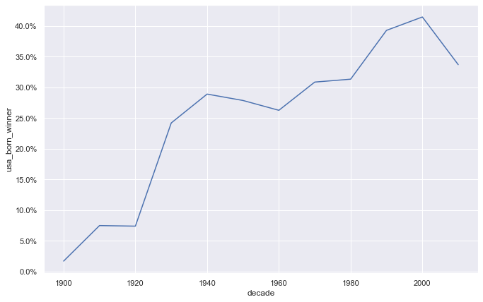

```python
# Calculating the proportion of USA born winners per decade
data['usa_born_winner'] = data['Birth Country'] == 'United States of America'
data['decade'] = (np.floor(data.Year/10)*10).astype(int)

# The proportions of USA born winners per decade, keeping th ecolumn names for plotting

prop_usa_winners = data.groupby('decade',as_index=False)['usa_born_winner'].mean()


# Setting the plotting theme & size of plots
sns.set()
plt.rcParams['figure.figsize'] = [11, 7]

# Plotting USA born winners
ax =  sns.lineplot(x='decade', y='usa_born_winner' , data=prop_usa_winners)

# Adding %-formatting to the y-axis
from matplotlib.ticker import PercentFormatter

ax.yaxis.set_major_formatter(PercentFormatter(1.0))
```

# 4. What is the gender of a typical Nobel Prize winner?

So the USA became the dominating winner of the Nobel Prize first in the 1930s and had kept the leading position ever since. But one group that was in the lead from the start, and never seems to let go, are men. Maybe it shouldn't come as a shock that there is some imbalance between how many male and female prize winners there are, but how significant is this imbalance? And is it better or worse within specific prize categories like physics, medicine, literature, etc.?

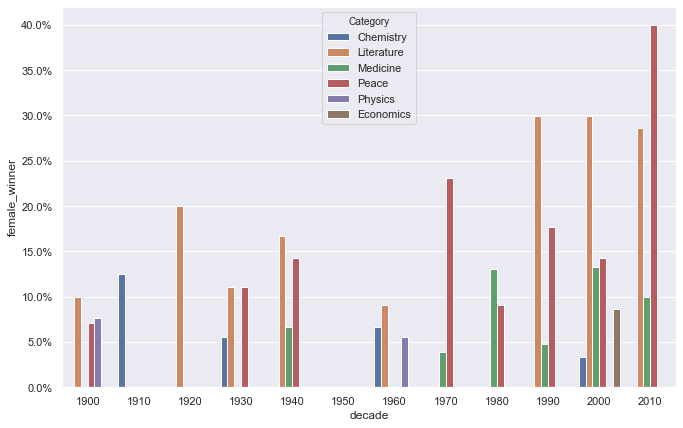

```python
# Calculating the proportion of female laureates per decade
data['female_winner'] = data['Sex'] == 'Female'
prop_female_winners = data.groupby(['decade','Category'],as_index=False)['female_winner'].mean()

# Plotting USA born winners with % winners on the y-axis

ax =   sns.barplot(x='decade', y='female_winner' , data=prop_female_winners, hue='Category')

ax.yaxis.set_major_formatter(PercentFormatter(1.0))
```

# 5. The first woman to win the Nobel Prize

Given this imbalance, who was the first woman to receive a Nobel Prize? And in what category?

```python
Female_winners = data[data.Sex =="Female"]

First_female = Female_winners.nsmallest(1,'Year').reset_index()

print('First female winner: ' + str(First_female['Full Name'][0]) + ' Category: ' + str(First_female['Category'][0]))
```

```
First female winner: Marie Curie, née Sklodowska Category: Physics
```

# 6. How old are you when you get the prize?

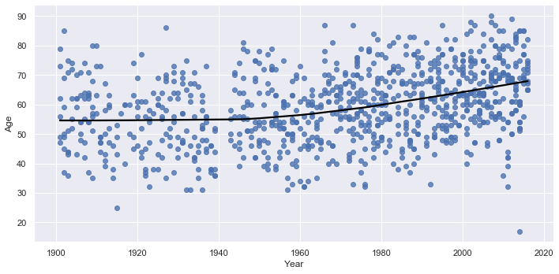

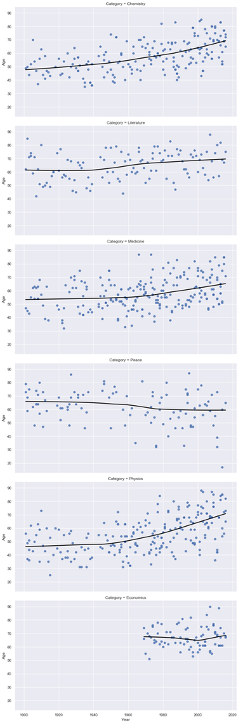

```python
# Converting birth_date from String to datetime

data['Birth Date']= pd.to_datetime(data['Birth Date'].astype(str), format='%Y-%m-%d', errors = 'coerce')

# Calculating the age of Nobel Prize winners
data['Age'] = data['Year']  -  data['Birth Date'].dt.year

# Plotting the age of Nobel Prize winners
sns.lmplot(x ='Year' , y='Age', data=data , lowess=True, aspect=2, line_kws={'color' : 'black'} )


# Plotting the age of Nobel Prize winners
sns.lmplot(x ='Year' , y='Age', data=data , row='Category', lowess=True, aspect=2, line_kws={'color' : 'black'} )
```